# Preface

Multiple approaches were attempted in exploratory graphing, however none of the techniques attempted led to any insights to the data, so those attempts are not documented here.

# Method

The data is cleaned by converting all columns in the data set except the ‘classe’ and initial five data field to numeric. To avoid imputing the data, all columns that contained no NA values across the entire dataset were selected for training. In this data set, this was sufficient for an acceptable error rate.

The Random Forest model was chosen due to accuracy observed in cross-validation of the training set. Cross validation is performed using createDataPartition to segment the training data into further training and testing data.

The “doMC” library is utilized to parallelize computations across multiple cores. Testing with PCA led to less accurate results, causing it to be abandoned in favor of using all features. Imputing the features that contain NAs may have resulted in a more accurate model.

# Results

```
##    Mode   FALSE    TRUE    NA's
## logical      57    5828       0
```

```
## [1] "The out of sample accuracy was 0.990314358538658"
```

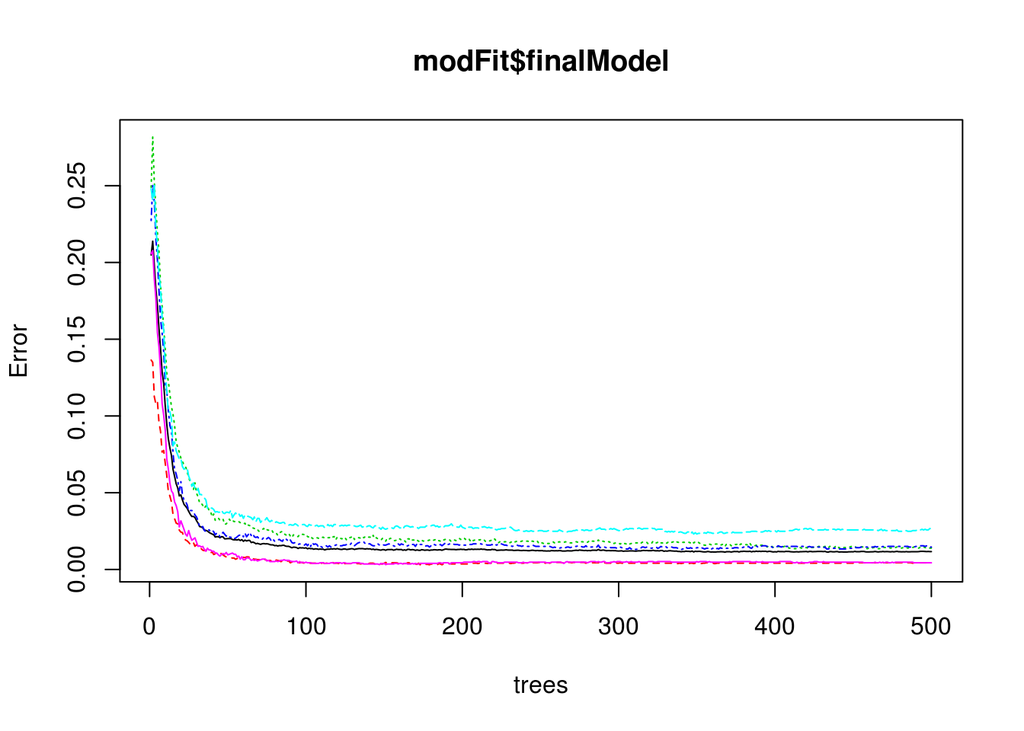

# Conclusion

Although the out of sample error rate was good, the submission portion of the project had a high error rate than expected (12 out of 20), suggesting that the model suffers from overfitting.